# Excercise 1

Nam Tran

## Part 1

In this part, I aimed to find a relationship that could dispel the notion that green ratings equate to higher rents, and thus higher revenues.I first started by grouping the buildings by whether or not they attained a green rating. Here we see some quick differences in rent, leasing rate etc.

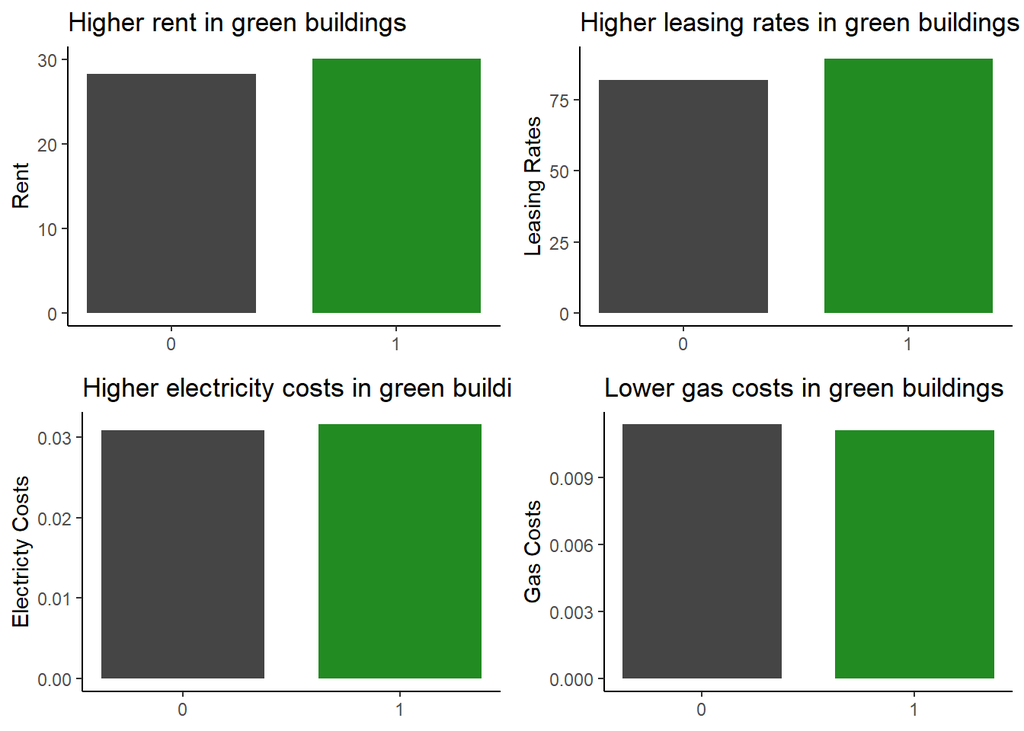

The pros of green buildings are evident here, but are the higher rents due to green ratings or other variables? Next, I examined the relationship between rent and age.

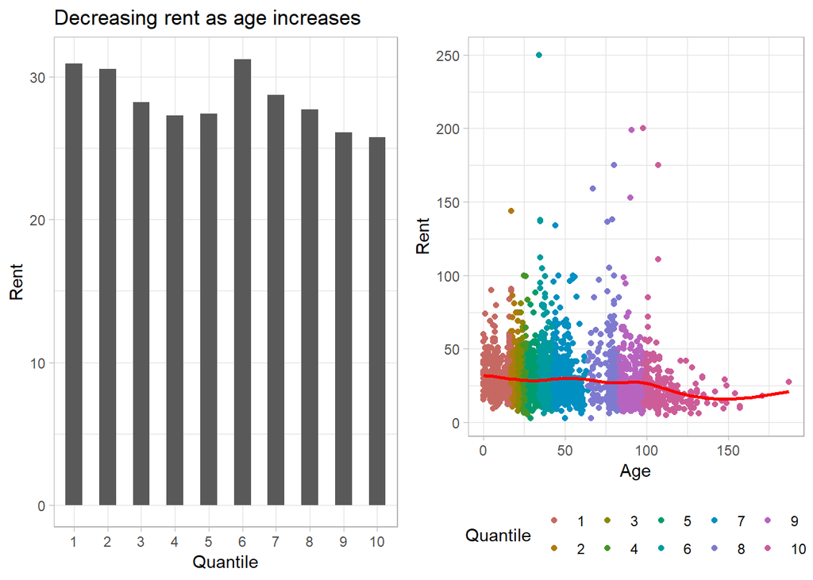

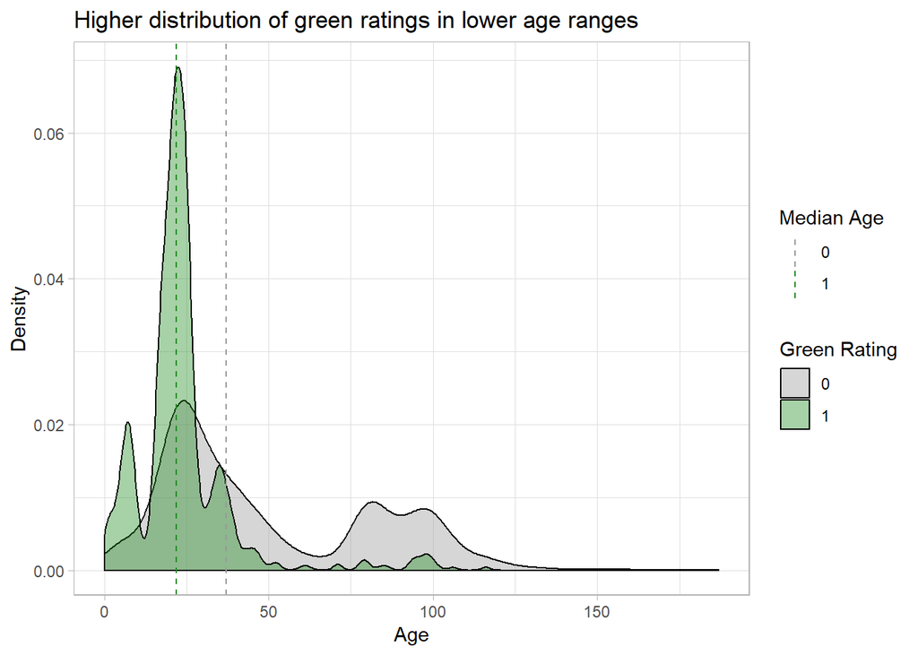

## Part 2

In this section, I mainly looked to answer two questions: What is the best time of day to fly to minimize delays and What is the best time of year to fly to minimize delays? Here are the results:

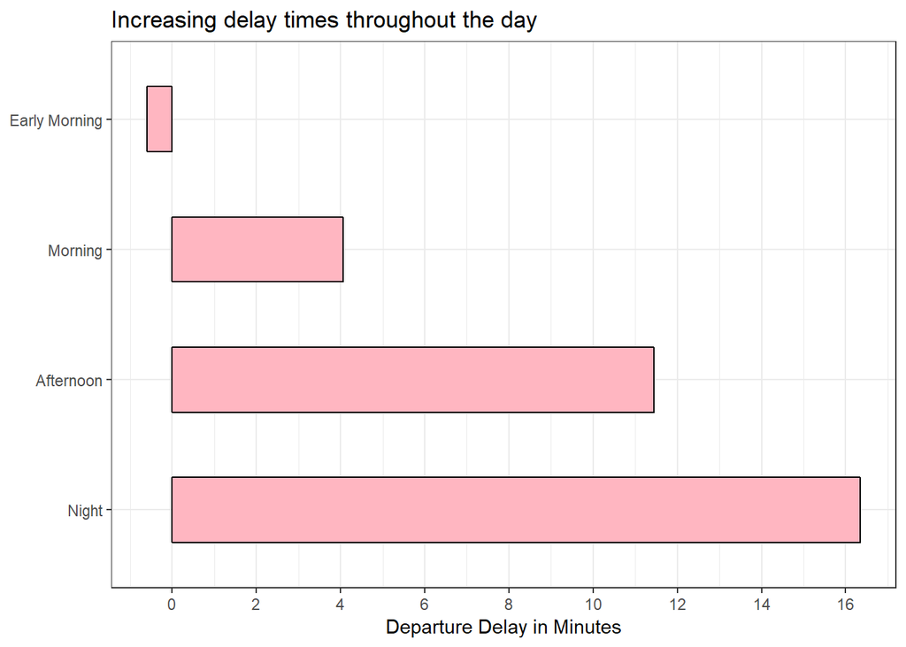

For the times of day, I divided the 24 hours into 4, 6 hour periods. Early morning flights ran from 12 a.m. to 6 a.m., morning flights from 6.a.m. to 12 p.m. and onwards. Unsurprisingly, the least amount of delays occured in the “early morning” time frame, and in fact, the average flight was ahead of time! When looking at seasons, the results are also rather unsurprisng.

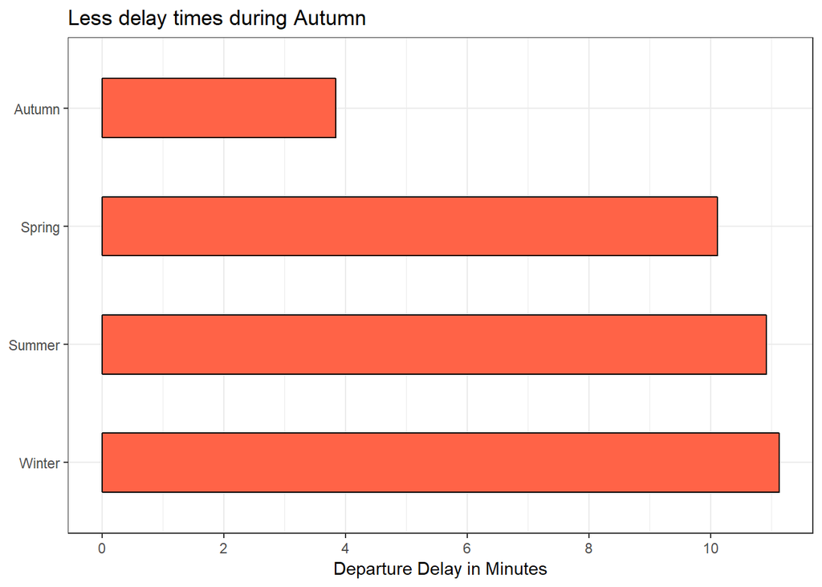

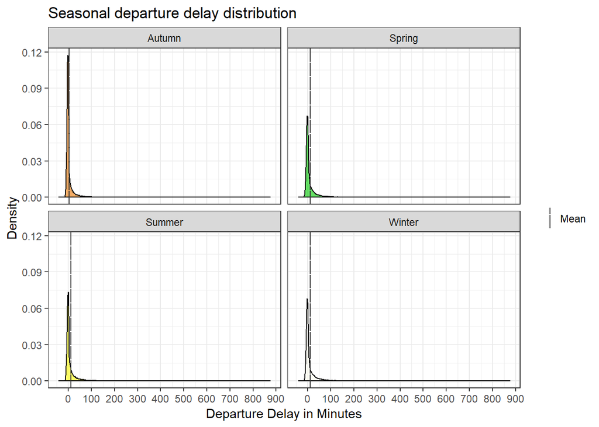

For the seasons, I divided the months by the traditional definitions. Winter runs from December to february, Spring going from March to May, Summer spanning June through August, and Autumn rounding it out from September to November. These results follow traditional intuition. Autumn doesn’t span many major holidays, and it is also one of the more fair weather seasons in this area. I quickly also looked at delay times by destination. The only major surprise is the absurdly high delay time from DSM which is Des Moines International Airport. Perhaps it is just a victim of severe outliers due to extreme weather or other unlikely delays.

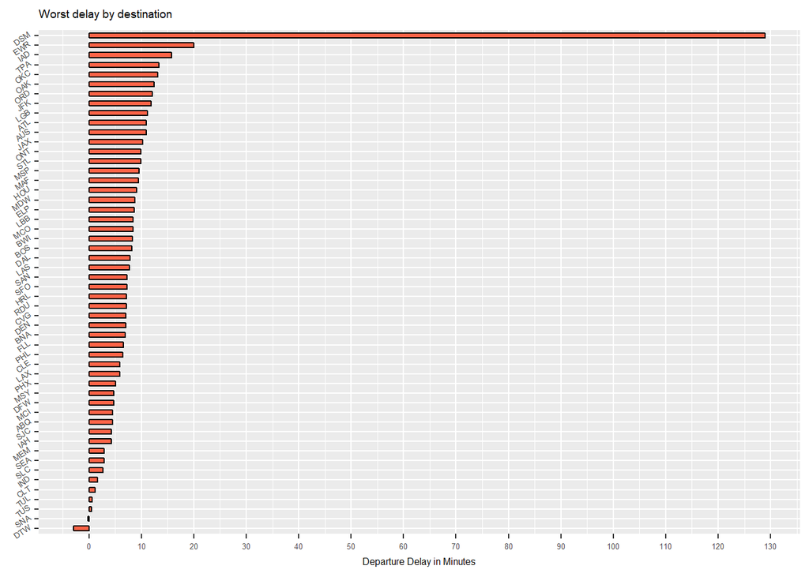

## Part 3

In this part, I begin by dividng the data by two specific trims, 350 and 65 AMG. Then after creating the training and testing splits, I use K-nearest neighbors to build a model. I run each trim from K = 3 to K = 100, finding the out of sample rmse for each. I then used the minimum rsme of the set to build the final predictive graph.

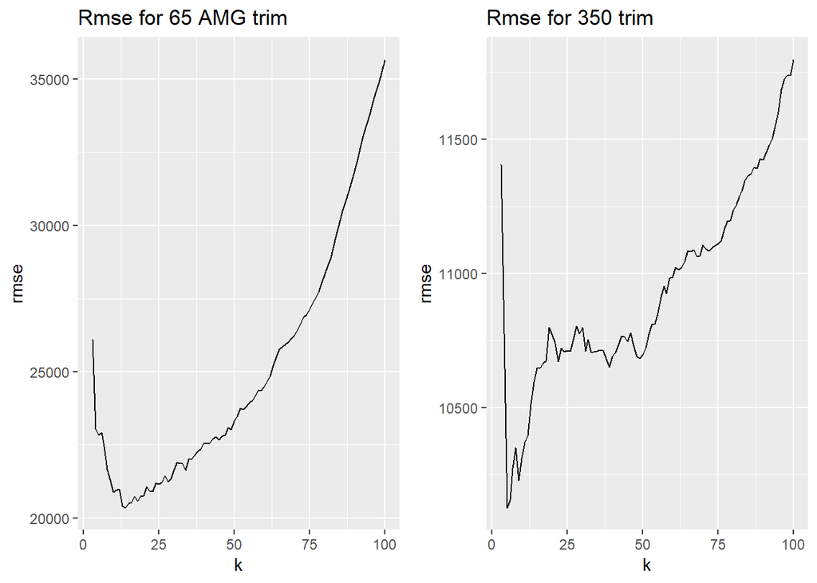

```
## Optimal K for 65 AMG trim:  14
```

```
## Optimal K for 350 trim:  5
```

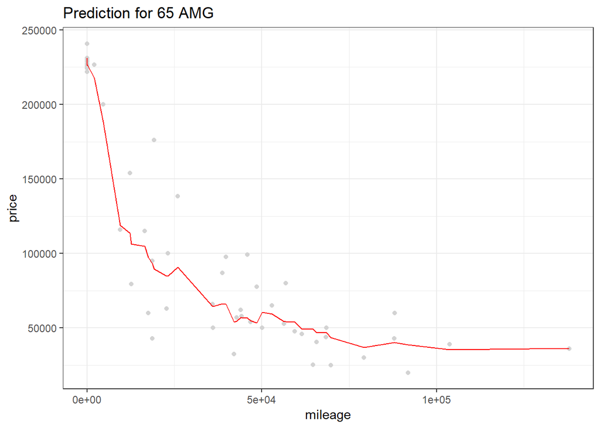

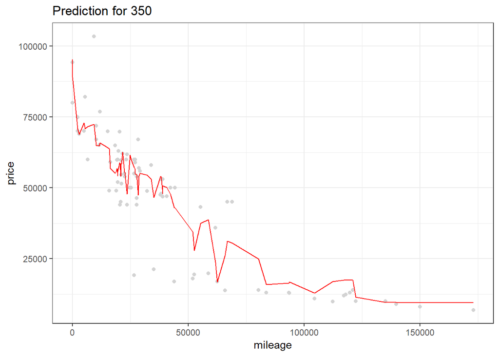